# Codebook Grouped

### Frequency.Body.Gyroscope.Mean.Z

Frequency Body Gyroscope Mean Z

#### Distribution

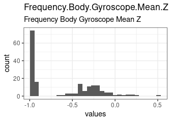

Distribution of values for Frequency.Body.Gyroscope.Mean.Z

0 missing values.

#### Summary statistics

| name | label | data_type | n_missing | complete_rate | min | median | max | mean | sd | hist |
| --- | --- | --- | --- | --- | --- | --- | --- | --- | --- | --- |
| Frequency.Body.Gyroscope.Mean.Z | Frequency Body Gyroscope Mean Z | numeric | 0 | 1 | -0.99 | -0.79 | 0.49 | -0.6043912 | 0.3842603 | ▇▂▅▁▁ |

### Frequency.Body.Gyroscope.Standard.Deviation.X

Frequency Body Gyroscope Standard Deviation X

#### Distribution

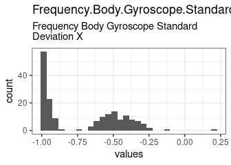

Distribution of values for Frequency.Body.Gyroscope.Standard.Deviation.X

0 missing values.

#### Summary statistics

| name | label | data_type | n_missing | complete_rate | min | median | max | mean | sd | hist |
| --- | --- | --- | --- | --- | --- | --- | --- | --- | --- | --- |
| Frequency.Body.Gyroscope.Standard.Deviation.X | Frequency Body Gyroscope Standard Deviation X | numeric | 0 | 1 | -0.99 | -0.81 | 0.2 | -0.7110357 | 0.272789 | ▇▂▅▁▁ |

### Frequency.Body.Gyroscope.Standard.Deviation.Y

Frequency Body Gyroscope Standard Deviation Y

#### Distribution

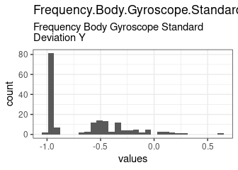

Distribution of values for Frequency.Body.Gyroscope.Standard.Deviation.Y

0 missing values.

#### Summary statistics

| name | label | data_type | n_missing | complete_rate | min | median | max | mean | sd | hist |
| --- | --- | --- | --- | --- | --- | --- | --- | --- | --- | --- |
| Frequency.Body.Gyroscope.Standard.Deviation.Y | Frequency Body Gyroscope Standard Deviation Y | numeric | 0 | 1 | -0.99 | -0.8 | 0.65 | -0.6454334 | 0.3634445 | ▇▅▂▁▁ |

### Frequency.Body.Gyroscope.Standard.Deviation.Z

Frequency Body Gyroscope Standard Deviation Z

#### Distribution

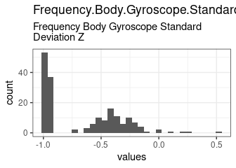

Distribution of values for Frequency.Body.Gyroscope.Standard.Deviation.Z

0 missing values.

#### Summary statistics

| name | label | data_type | n_missing | complete_rate | min | median | max | mean | sd | hist |
| --- | --- | --- | --- | --- | --- | --- | --- | --- | --- | --- |
| Frequency.Body.Gyroscope.Standard.Deviation.Z | Frequency Body Gyroscope Standard Deviation Z | numeric | 0 | 1 | -0.99 | -0.82 | 0.52 | -0.6577466 | 0.3362014 | ▇▃▃▁▁ |

### Frequency.Body.Gyroscope.Mean.Frequency.X

Frequency Body Gyroscope Mean Frequency X

#### Distribution

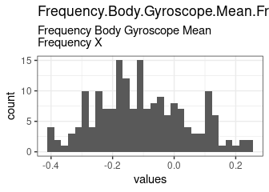

Distribution of values for Frequency.Body.Gyroscope.Mean.Frequency.X

0 missing values.

#### Summary statistics

| name | label | data_type | n_missing | complete_rate | min | median | max | mean | sd | hist |
| --- | --- | --- | --- | --- | --- | --- | --- | --- | --- | --- |
| Frequency.Body.Gyroscope.Mean.Frequency.X | Frequency Body Gyroscope Mean Frequency X | numeric | 0 | 1 | -0.4 | -0.12 | 0.25 | -0.104551 | 0.1480975 | ▃▇▇▅▂ |

### Frequency.Body.Gyroscope.Mean.Frequency.Y

Frequency Body Gyroscope Mean Frequency Y

#### Distribution

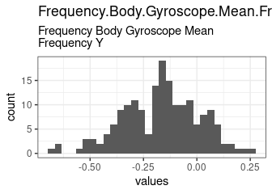

Distribution of values for Frequency.Body.Gyroscope.Mean.Frequency.Y

0 missing values.

#### Summary statistics

| name | label | data_type | n_missing | complete_rate | min | median | max | mean | sd | hist |
| --- | --- | --- | --- | --- | --- | --- | --- | --- | --- | --- |
| Frequency.Body.Gyroscope.Mean.Frequency.Y | Frequency Body Gyroscope Mean Frequency Y | numeric | 0 | 1 | -0.67 | -0.16 | 0.27 | -0.1674075 | 0.1788011 | ▁▅▇▆▂ |

### Frequency.Body.Gyroscope.Mean.Frequency.Z

Frequency Body Gyroscope Mean Frequency Z

#### Distribution

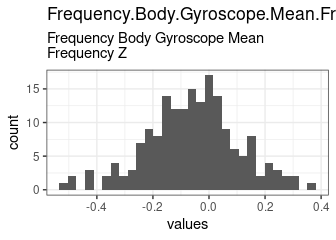

Distribution of values for Frequency.Body.Gyroscope.Mean.Frequency.Z

0 missing values.

#### Summary statistics

| name | label | data_type | n_missing | complete_rate | min | median | max | mean | sd | hist |
| --- | --- | --- | --- | --- | --- | --- | --- | --- | --- | --- |
| Frequency.Body.Gyroscope.Mean.Frequency.Z | Frequency Body Gyroscope Mean Frequency Z | numeric | 0 | 1 | -0.51 | -0.051 | 0.38 | -0.0571809 | 0.1652298 | ▁▃▇▃▁ |

### Frequency.Body.Accelerometer.Magnitude.Mean

Frequency Body Accelerometer Magnitude Mean

#### Distribution

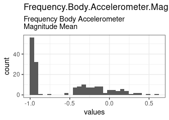

Distribution of values for Frequency.Body.Accelerometer.Magnitude.Mean

0 missing values.

#### Summary statistics

| name | label | data_type | n_missing | complete_rate | min | median | max | mean | sd | hist |
| --- | --- | --- | --- | --- | --- | --- | --- | --- | --- | --- |
| Frequency.Body.Accelerometer.Magnitude.Mean | Frequency Body Accelerometer Magnitude Mean | numeric | 0 | 1 | -0.99 | -0.67 | 0.59 | -0.5365167 | 0.4516451 | ▇▂▃▂▁ |

### Frequency.Body.Accelerometer.Magnitude.Standard.Deviation

Frequency Body Accelerometer Magnitude Standard Deviation

#### Distribution

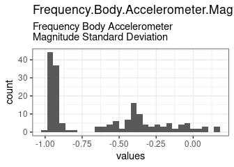

Distribution of values for Frequency.Body.Accelerometer.Magnitude.Standard.Deviation

0 missing values.

#### Summary statistics

| name | label | data_type | n_missing | complete_rate | min | median | max | mean | sd | hist |
| --- | --- | --- | --- | --- | --- | --- | --- | --- | --- | --- |
| Frequency.Body.Accelerometer.Magnitude.Standard.Deviation | Frequency Body Accelerometer Magnitude Standard Deviation | numeric | 0 | 1 | -0.99 | -0.65 | 0.18 | -0.6209633 | 0.3529148 | ▇▁▃▂▁ |

### Frequency.Body.Accelerometer.Magnitude.Mean.Frequency

Frequency Body Accelerometer Magnitude Mean Frequency

#### Distribution

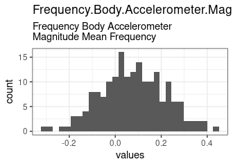

Distribution of values for Frequency.Body.Accelerometer.Magnitude.Mean.Frequency

0 missing values.

#### Summary statistics

| name | label | data_type | n_missing | complete_rate | min | median | max | mean | sd | hist |
| --- | --- | --- | --- | --- | --- | --- | --- | --- | --- | --- |
| Frequency.Body.Accelerometer.Magnitude.Mean.Frequency | Frequency Body Accelerometer Magnitude Mean Frequency | numeric | 0 | 1 | -0.31 | 0.081 | 0.44 | 0.0761282 | 0.1404479 | ▁▅▇▅▁ |

### Frequency.Body.Accelerometer.Jerk.Magnitude.Mean

Frequency Body Accelerometer Jerk Magnitude Mean

#### Distribution

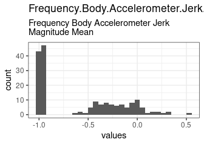

Distribution of values for Frequency.Body.Accelerometer.Jerk.Magnitude.Mean

0 missing values.

#### Summary statistics

| name | label | data_type | n_missing | complete_rate | min | median | max | mean | sd | hist |
| --- | --- | --- | --- | --- | --- | --- | --- | --- | --- | --- |
| Frequency.Body.Accelerometer.Jerk.Magnitude.Mean | Frequency Body Accelerometer Jerk Magnitude Mean | numeric | 0 | 1 | -0.99 | -0.79 | 0.54 | -0.5756175 | 0.4312321 | ▇▂▃▂▁ |

### Frequency.Body.Accelerometer.Jerk.Magnitude.Standard.Deviation

Frequency Body Accelerometer Jerk Magnitude Standard Deviation

#### Distribution

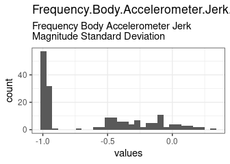

Distribution of values for Frequency.Body.Accelerometer.Jerk.Magnitude.Standard.Deviation

0 missing values.

#### Summary statistics

| name | label | data_type | n_missing | complete_rate | min | median | max | mean | sd | hist |
| --- | --- | --- | --- | --- | --- | --- | --- | --- | --- | --- |
| Frequency.Body.Accelerometer.Jerk.Magnitude.Standard.Deviation | Frequency Body Accelerometer Jerk Magnitude Standard Deviation | numeric | 0 | 1 | -0.99 | -0.81 | 0.32 | -0.5991609 | 0.4086668 | ▇▁▃▂▁ |

### Frequency.Body.Accelerometer.Jerk.Magnitude.Mean.Frequency

Frequency Body Accelerometer Jerk Magnitude Mean Frequency

#### Distribution

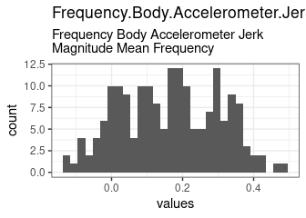

Distribution of values for Frequency.Body.Accelerometer.Jerk.Magnitude.Mean.Frequency

0 missing values.

#### Summary statistics

| name | label | data_type | n_missing | complete_rate | min | median | max | mean | sd | hist |
| --- | --- | --- | --- | --- | --- | --- | --- | --- | --- | --- |
| Frequency.Body.Accelerometer.Jerk.Magnitude.Mean.Frequency | Frequency Body Accelerometer Jerk Magnitude Mean Frequency | numeric | 0 | 1 | -0.13 | 0.17 | 0.49 | 0.1625459 | 0.13783 | ▃▇▇▇▂ |

### Frequency.Body.Gyroscope.Magnitude.Mean

Frequency Body Gyroscope Magnitude Mean

#### Distribution

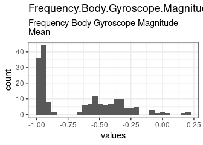

Distribution of values for Frequency.Body.Gyroscope.Magnitude.Mean

0 missing values.

#### Summary statistics

| name | label | data_type | n_missing | complete_rate | min | median | max | mean | sd | hist |
| --- | --- | --- | --- | --- | --- | --- | --- | --- | --- | --- |
| Frequency.Body.Gyroscope.Magnitude.Mean | Frequency Body Gyroscope Magnitude Mean | numeric | 0 | 1 | -0.99 | -0.77 | 0.2 | -0.6670991 | 0.3181183 | ▇▂▃▁▁ |

### Frequency.Body.Gyroscope.Magnitude.Standard.Deviation

Frequency Body Gyroscope Magnitude Standard Deviation

#### Distribution

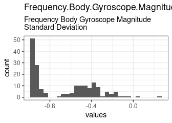

Distribution of values for Frequency.Body.Gyroscope.Magnitude.Standard.Deviation

0 missing values.

#### Summary statistics

| name | label | data_type | n_missing | complete_rate | min | median | max | mean | sd | hist |
| --- | --- | --- | --- | --- | --- | --- | --- | --- | --- | --- |
| Frequency.Body.Gyroscope.Magnitude.Standard.Deviation | Frequency Body Gyroscope Magnitude Standard Deviation | numeric | 0 | 1 | -0.98 | -0.77 | 0.24 | -0.6723223 | 0.2931842 | ▇▂▅▁▁ |

### Frequency.Body.Gyroscope.Magnitude.Mean.Frequency

Frequency Body Gyroscope Magnitude Mean Frequency

#### Distribution

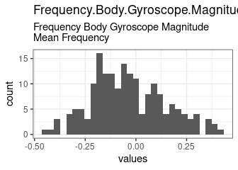

Distribution of values for Frequency.Body.Gyroscope.Magnitude.Mean.Frequency

0 missing values.

#### Summary statistics

| name | label | data_type | n_missing | complete_rate | min | median | max | mean | sd | hist |
| --- | --- | --- | --- | --- | --- | --- | --- | --- | --- | --- |
| Frequency.Body.Gyroscope.Magnitude.Mean.Frequency | Frequency Body Gyroscope Magnitude Mean Frequency | numeric | 0 | 1 | -0.46 | -0.054 | 0.41 | -0.0360322 | 0.1807351 | ▂▇▇▅▂ |

### Frequency.Body.Gyroscope.Jerk.Magnitude.Mean

Frequency Body Gyroscope Jerk Magnitude Mean

#### Distribution

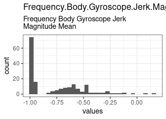

Distribution of values for Frequency.Body.Gyroscope.Jerk.Magnitude.Mean

0 missing values.

#### Summary statistics

| name | label | data_type | n_missing | complete_rate | min | median | max | mean | sd | hist |
| --- | --- | --- | --- | --- | --- | --- | --- | --- | --- | --- |
| Frequency.Body.Gyroscope.Jerk.Magnitude.Mean | Frequency Body Gyroscope Jerk Magnitude Mean | numeric | 0 | 1 | -1 | -0.88 | 0.15 | -0.7563853 | 0.2628722 | ▇▅▂▁▁ |

### Frequency.Body.Gyroscope.Jerk.Magnitude.Standard.Deviation

Frequency Body Gyroscope Jerk Magnitude Standard Deviation

#### Distribution

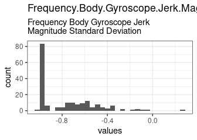

Distribution of values for Frequency.Body.Gyroscope.Jerk.Magnitude.Standard.Deviation

0 missing values.

#### Summary statistics

| name | label | data_type | n_missing | complete_rate | min | median | max | mean | sd | hist |
| --- | --- | --- | --- | --- | --- | --- | --- | --- | --- | --- |
| Frequency.Body.Gyroscope.Jerk.Magnitude.Standard.Deviation | Frequency Body Gyroscope Jerk Magnitude Standard Deviation | numeric | 0 | 1 | -1 | -0.89 | 0.29 | -0.7715171 | 0.2504248 | ▇▃▁▁▁ |

### Frequency.Body.Gyroscope.Jerk.Magnitude.Mean.Frequency

Frequency Body Gyroscope Jerk Magnitude Mean Frequency

#### Distribution

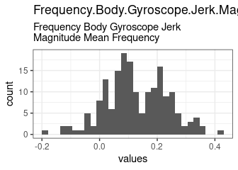

Distribution of values for Frequency.Body.Gyroscope.Jerk.Magnitude.Mean.Frequency

0 missing values.

#### Summary statistics

| name | label | data_type | n_missing | complete_rate | min | median | max | mean | sd | hist |
| --- | --- | --- | --- | --- | --- | --- | --- | --- | --- | --- |
| Frequency.Body.Gyroscope.Jerk.Magnitude.Mean.Frequency | Frequency Body Gyroscope Jerk Magnitude Mean Frequency | numeric | 0 | 1 | -0.18 | 0.11 | 0.43 | 0.1259225 | 0.1083232 | ▁▅▇▆▁ |

### Angle.Time.Body.Accelerometer.Mean.Gravity

Angle Time Body Accelerometer Mean Gravity

#### Distribution

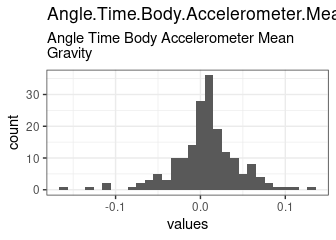

Distribution of values for Angle.Time.Body.Accelerometer.Mean.Gravity

0 missing values.

#### Summary statistics

| name | label | data_type | n_missing | complete_rate | min | median | max | mean | sd | hist |
| --- | --- | --- | --- | --- | --- | --- | --- | --- | --- | --- |
| Angle.Time.Body.Accelerometer.Mean.Gravity | Angle Time Body Accelerometer Mean Gravity | numeric | 0 | 1 | -0.16 | 0.0079 | 0.13 | 0.0065557 | 0.0396044 | ▁▁▇▇▁ |

### Angle.Time.Body.Accelerometer.Jerk.Mean.Gravity.Mean

Angle Time Body Accelerometer Jerk Mean Gravity Mean

#### Distribution

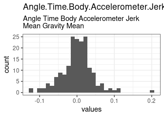

Distribution of values for Angle.Time.Body.Accelerometer.Jerk.Mean.Gravity.Mean

0 missing values.

#### Summary statistics

| name | label | data_type | n_missing | complete_rate | min | median | max | mean | sd | hist |
| --- | --- | --- | --- | --- | --- | --- | --- | --- | --- | --- |
| Angle.Time.Body.Accelerometer.Jerk.Mean.Gravity.Mean | Angle Time Body Accelerometer Jerk Mean Gravity Mean | numeric | 0 | 1 | -0.12 | 0.0031 | 0.2 | 0.0006439 | 0.0427632 | ▂▇▆▁▁ |

### Angle.Time.Body.Gyroscope.Mean.Gravity.Mean

Angle Time Body Gyroscope Mean Gravity Mean

#### Distribution

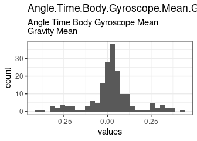

Distribution of values for Angle.Time.Body.Gyroscope.Mean.Gravity.Mean

0 missing values.

#### Summary statistics

| name | label | data_type | n_missing | complete_rate | min | median | max | mean | sd | hist |
| --- | --- | --- | --- | --- | --- | --- | --- | --- | --- | --- |
| Angle.Time.Body.Gyroscope.Mean.Gravity.Mean | Angle Time Body Gyroscope Mean Gravity Mean | numeric | 0 | 1 | -0.39 | 0.021 | 0.44 | 0.0219317 | 0.1401276 | ▁▁▇▁▁ |

### Angle.Time.Body.Gyroscope.Jerk.Mean.Gravity.Mean

Angle Time Body Gyroscope Jerk Mean Gravity Mean

#### Distribution

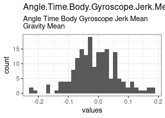

Distribution of values for Angle.Time.Body.Gyroscope.Jerk.Mean.Gravity.Mean

0 missing values.

#### Summary statistics

| name | label | data_type | n_missing | complete_rate | min | median | max | mean | sd | hist |
| --- | --- | --- | --- | --- | --- | --- | --- | --- | --- | --- |
| Angle.Time.Body.Gyroscope.Jerk.Mean.Gravity.Mean | Angle Time Body Gyroscope Jerk Mean Gravity Mean | numeric | 0 | 1 | -0.22 | -0.016 | 0.18 | -0.0113732 | 0.0729629 | ▁▃▇▅▁ |

### Angle.X.Gravity.Mean

Angle X Gravity Mean

#### Distribution

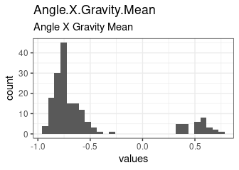

Distribution of values for Angle.X.Gravity.Mean

0 missing values.

#### Summary statistics

| name | label | data_type | n_missing | complete_rate | min | median | max | mean | sd | hist |
| --- | --- | --- | --- | --- | --- | --- | --- | --- | --- | --- |
| Angle.X.Gravity.Mean | Angle X Gravity Mean | numeric | 0 | 1 | -0.95 | -0.74 | 0.74 | -0.5243065 | 0.481228 | ▇▂▁▁▂ |

### Angle.Y.Gravity.Mean

Angle Y Gravity Mean

#### Distribution

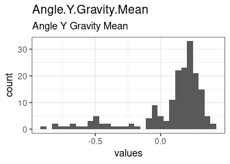

Distribution of values for Angle.Y.Gravity.Mean

0 missing values.

#### Summary statistics

| name | label | data_type | n_missing | complete_rate | min | median | max | mean | sd | hist |
| --- | --- | --- | --- | --- | --- | --- | --- | --- | --- | --- |
| Angle.Y.Gravity.Mean | Angle Y Gravity Mean | numeric | 0 | 1 | -0.87 | 0.17 | 0.42 | 0.0786534 | 0.2784784 | ▁▁▁▅▇ |

### Angle.Z.Gravity.Mean

Angle Z Gravity Mean

#### Distribution

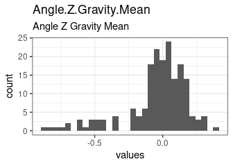

Distribution of values for Angle.Z.Gravity.Mean

0 missing values.

#### Summary statistics

| name | label | data_type | n_missing | complete_rate | min | median | max | mean | sd | hist |
| --- | --- | --- | --- | --- | --- | --- | --- | --- | --- | --- |
| Angle.Z.Gravity.Mean | Angle Z Gravity Mean | numeric | 0 | 1 | -0.87 | 0.0051 | 0.39 | -0.0404362 | 0.2308332 | ▁▁▁▇▂ |

## Codebook table

| name | label | data_type | n_missing | complete_rate | n_unique | empty | min | median | max | mean | sd | whitespace | hist |
| --- | --- | --- | --- | --- | --- | --- | --- | --- | --- | --- | --- | --- | --- |
| subject | subject | numeric | 0 | 1 | NA | NA | 1.000 | 15.5000 | 30.0000 | 15.5000000 | 8.6795850 | NA | ▇▇▇▇▇ |
| activity | activity | character | 0 | 1 | 6 | 0 | 6 | NA | 18 | NA | NA | 0 | NA |
| Time.Body.Accelerometer.Mean.X | Time Body Accelerometer Mean X | numeric | 0 | 1 | NA | NA | 0.222 | 0.2770 | 0.3015 | 0.2743027 | 0.0121646 | NA | ▁▁▂▇▂ |
| Time.Body.Accelerometer.Mean.Y | Time Body Accelerometer Mean Y | numeric | 0 | 1 | NA | NA | -0.041 | -0.0173 | -0.0013 | -0.0178755 | 0.0057712 | NA | ▁▂▇▇▁ |
| Time.Body.Accelerometer.Mean.Z | Time Body Accelerometer Mean Z | numeric | 0 | 1 | NA | NA | -0.153 | -0.1082 | -0.0754 | -0.1091638 | 0.0095820 | NA | ▁▁▇▅▁ |
| Time.Body.Accelerometer.Standard.Deviation.X | Time Body Accelerometer Standard Deviation X | numeric | 0 | 1 | NA | NA | -0.996 | -0.7526 | 0.6269 | -0.5576901 | 0.4516911 | NA | ▇▂▅▂▁ |
| Time.Body.Accelerometer.Standard.Deviation.Y | Time Body Accelerometer Standard Deviation Y | numeric | 0 | 1 | NA | NA | -0.990 | -0.5090 | 0.6169 | -0.4604626 | 0.4965650 | NA | ▇▁▅▃▁ |
| Time.Body.Accelerometer.Standard.Deviation.Z | Time Body Accelerometer Standard Deviation Z | numeric | 0 | 1 | NA | NA | -0.988 | -0.6518 | 0.6090 | -0.5755602 | 0.3955439 | NA | ▇▂▅▁▁ |
| Time.Gravity.Accelerometer.Mean.X | Time Gravity Accelerometer Mean X | numeric | 0 | 1 | NA | NA | -0.680 | 0.9208 | 0.9745 | 0.6974775 | 0.4872534 | NA | ▁▁▁▁▇ |
| Time.Gravity.Accelerometer.Mean.Y | Time Gravity Accelerometer Mean Y | numeric | 0 | 1 | NA | NA | -0.480 | -0.1278 | 0.9566 | -0.0162128 | 0.3452376 | NA | ▇▇▂▁▂ |
| Time.Gravity.Accelerometer.Mean.Z | Time Gravity Accelerometer Mean Z | numeric | 0 | 1 | NA | NA | -0.495 | 0.0238 | 0.9579 | 0.0741279 | 0.2887919 | NA | ▂▇▃▁▁ |
| Time.Gravity.Accelerometer.Standard.Deviation.X | Time Gravity Accelerometer Standard Deviation X | numeric | 0 | 1 | NA | NA | -0.997 | -0.9695 | -0.8296 | -0.9637525 | 0.0250344 | NA | ▇▆▁▁▁ |
| Time.Gravity.Accelerometer.Standard.Deviation.Y | Time Gravity Accelerometer Standard Deviation Y | numeric | 0 | 1 | NA | NA | -0.994 | -0.9590 | -0.6436 | -0.9524296 | 0.0326557 | NA | ▇▁▁▁▁ |
| Time.Gravity.Accelerometer.Standard.Deviation.Z | Time Gravity Accelerometer Standard Deviation Z | numeric | 0 | 1 | NA | NA | -0.991 | -0.9450 | -0.6102 | -0.9364010 | 0.0402912 | NA | ▇▂▁▁▁ |
| Time.Body.Accelerometer.Jerk.Mean.X | Time Body Accelerometer Jerk Mean X | numeric | 0 | 1 | NA | NA | 0.043 | 0.0764 | 0.1302 | 0.0794736 | 0.0125880 | NA | ▁▇▃▂▁ |
| Time.Body.Accelerometer.Jerk.Mean.Y | Time Body Accelerometer Jerk Mean Y | numeric | 0 | 1 | NA | NA | -0.039 | 0.0095 | 0.0568 | 0.0075652 | 0.0135764 | NA | ▁▃▇▂▁ |
| Time.Body.Accelerometer.Jerk.Mean.Z | Time Body Accelerometer Jerk Mean Z | numeric | 0 | 1 | NA | NA | -0.067 | -0.0039 | 0.0381 | -0.0049534 | 0.0134621 | NA | ▁▁▇▇▁ |
| Time.Body.Accelerometer.Jerk.Standard.Deviation.X | Time Body Accelerometer Jerk Standard Deviation X | numeric | 0 | 1 | NA | NA | -0.995 | -0.8104 | 0.5443 | -0.5949467 | 0.4175865 | NA | ▇▂▅▂▁ |
| Time.Body.Accelerometer.Jerk.Standard.Deviation.Y | Time Body Accelerometer Jerk Standard Deviation Y | numeric | 0 | 1 | NA | NA | -0.990 | -0.7756 | 0.3553 | -0.5654147 | 0.4330871 | NA | ▇▁▃▃▁ |
| Time.Body.Accelerometer.Jerk.Standard.Deviation.Z | Time Body Accelerometer Jerk Standard Deviation Z | numeric | 0 | 1 | NA | NA | -0.993 | -0.8837 | 0.0310 | -0.7359577 | 0.2768479 | NA | ▇▂▃▁▁ |
| Time.Body.Gyroscope.Mean.X | Time Body Gyroscope Mean X | numeric | 0 | 1 | NA | NA | -0.206 | -0.0287 | 0.1927 | -0.0324372 | 0.0540518 | NA | ▁▂▇▁▁ |
| Time.Body.Gyroscope.Mean.Y | Time Body Gyroscope Mean Y | numeric | 0 | 1 | NA | NA | -0.204 | -0.0732 | 0.0275 | -0.0742596 | 0.0355415 | NA | ▁▁▇▃▁ |
| Time.Body.Gyroscope.Mean.Z | Time Body Gyroscope Mean Z | numeric | 0 | 1 | NA | NA | -0.072 | 0.0851 | 0.1791 | 0.0874446 | 0.0362125 | NA | ▁▁▃▇▂ |
| Time.Body.Gyroscope.Standard.Deviation.X | Time Body Gyroscope Standard Deviation X | numeric | 0 | 1 | NA | NA | -0.994 | -0.7890 | 0.2677 | -0.6916399 | 0.2910189 | NA | ▇▃▅▁▁ |
| Time.Body.Gyroscope.Standard.Deviation.Y | Time Body Gyroscope Standard Deviation Y | numeric | 0 | 1 | NA | NA | -0.994 | -0.8017 | 0.4765 | -0.6533020 | 0.3520252 | NA | ▇▅▂▁▁ |
| Time.Body.Gyroscope.Standard.Deviation.Z | Time Body Gyroscope Standard Deviation Z | numeric | 0 | 1 | NA | NA | -0.986 | -0.8010 | 0.5649 | -0.6164353 | 0.3730264 | NA | ▇▂▅▁▁ |
| Time.Body.Gyroscope.Jerk.Mean.X | Time Body Gyroscope Jerk Mean X | numeric | 0 | 1 | NA | NA | -0.157 | -0.0987 | -0.0221 | -0.0960568 | 0.0233458 | NA | ▁▂▇▁▁ |
| Time.Body.Gyroscope.Jerk.Mean.Y | Time Body Gyroscope Jerk Mean Y | numeric | 0 | 1 | NA | NA | -0.077 | -0.0411 | -0.0132 | -0.0426928 | 0.0095320 | NA | ▁▂▇▃▁ |
| Time.Body.Gyroscope.Jerk.Mean.Z | Time Body Gyroscope Jerk Mean Z | numeric | 0 | 1 | NA | NA | -0.092 | -0.0534 | -0.0069 | -0.0548019 | 0.0123470 | NA | ▁▅▇▁▁ |
| Time.Body.Gyroscope.Jerk.Standard.Deviation.X | Time Body Gyroscope Jerk Standard Deviation X | numeric | 0 | 1 | NA | NA | -0.997 | -0.8396 | 0.1791 | -0.7036327 | 0.3008361 | NA | ▇▂▃▂▁ |

[output cut: 58 more lines]

**JSON-LD metadata**